# R Notebook

```r
setwd("C:\\DESeq2_Practice")
getwd()
```

```
[1] "C:/DESeq2_Practice"
```

```r
library(DESeq2)
library("ggplot2")
```

```r
packageVersion("DESeq2")
```

```
[1] ‘1.46.0’
```

```r
rawCount <- readRDS("data\\RNA-seq_RawCounts.Rds")
rawCount
```

|  | 12S | 13S | 14S | 15S | 16S | 17S | 18S | 19S | 20S | 21S | 12N | 13N | 14N | 15N | 16N | 17N | 18N | 19N | 20N | 21N | 12T | 13T | 14T | 15T | 16T | 17T | 18T | 19T | 20T | … |
| --- | --- | --- | --- | --- | --- | --- | --- | --- | --- | --- | --- | --- | --- | --- | --- | --- | --- | --- | --- | --- | --- | --- | --- | --- | --- | --- | --- | --- | --- | --- |
| ENSG00000223972 | 2 | 5 | 5 | 9 | 13 | 0 | 11 | 8 | 3 | 14 | 2 | 7 | 5 | 8 | 4 | 7 | 8 | 6 | 8 | 2 | 1 | 6 | 4 | 19 | 8 | 4 | 5 | 7 | 3 | … |
| ENSG00000227232 | 29 | 62 | 50 | 64 | 67 | 63 | 69 | 73 | 73 | 40 | 67 | 72 | 41 | 59 | 49 | 55 | 86 | 69 | 30 | 87 | 45 | 67 | 46 | 41 | 73 | 42 | 128 | 94 | 78 | … |
| ENSG00000243485 | 1 | 6 | 3 | 5 | 3 | 0 | 1 | 6 | 2 | 2 | 3 | 3 | 6 | 0 | 0 | 2 | 0 | 8 | 4 | 3 | 0 | 4 | 2 | 5 | 2 | 1 | 6 | 4 | 2 | … |
| ENSG00000237613 | 1 | 3 | 3 | 13 | 2 | 0 | 10 | 11 | 6 | 8 | 1 | 6 | 3 | 3 | 5 | 5 | 5 | 11 | 9 | 12 | 0 | 4 | 4 | 17 | 2 | 2 | 7 | 5 | 2 | … |
| ENSG00000268020 | 0 | 0 | 0 | 0 | 2 | 0 | 0 | 1 | 0 | 0 | 0 | 0 | 2 | 0 | 1 | 1 | 1 | 1 | 1 | 0 | 0 | 2 | 0 | 1 | 0 | 1 | 0 | 0 | 0 | … |
| ENSG00000240361 | 0 | 0 | 1 | 0 | 0 | 0 | 0 | 0 | 1 | 0 | 0 | 0 | 1 | 0 | 0 | 0 | 2 | 0 | 2 | 0 | 0 | 0 | 0 | 1 | 0 | 0 | 0 | 0 | 0 | … |
| ENSG00000186092 | 0 | 2 | 0 | 0 | 0 | 0 | 1 | 0 | 0 | 0 | 0 | 0 | 2 | 0 | 0 | 0 | 0 | 1 | 0 | 0 | 0 | 0 | 0 | 1 | 0 | 0 | 0 | 0 | 1 | … |
| ENSG00000238009 | 5 | 3 | 4 | 8 | 10 | 4 | 8 | 11 | 9 | 5 | 4 | 6 | 18 | 7 | 5 | 8 | 18 | 13 | 3 | 6 | 9 | 14 | 5 | 8 | 8 | 19 | 8 | 16 | 8 | … |
| ENSG00000239945 | 0 | 0 | 0 | 0 | 0 | 0 | 0 | 0 | 0 | 0 | 0 | 0 | 0 | 0 | 0 | 0 | 0 | 0 | 0 | 0 | 0 | 0 | 0 | 0 | 0 | 0 | 0 | 0 | 0 | … |
| ENSG00000233750 | 1 | 3 | 3 | 10 | 10 | 0 | 3 | 3 | 7 | 11 | 6 | 5 | 11 | 5 | 5 | 5 | 4 | 9 | 6 | 5 | 2 | 7 | 2 | 9 | 3 | 1 | 14 | 3 | 10 | … |

[output cut: 990 more lines]

```r
dim(rawCount)
```

```
[1] 57905    30
```

# Filtering

# A gene passes the filter if any 3 or more samples have ≥10 reads.

```r
numberOfSamples <- 3
keep <- rowSums(rawCount >= 10) >= numberOfSamples
rawCount <- rawCount[keep,]

dim(rawCount)
```

```
[1] 25042    30
```

```r
tissueType <- factor(c(rep("Stroma",10),rep("Normal",10),rep("Tumor",10)))
levels(tissueType)
```

```
[1] "Normal" "Stroma" "Tumor"
```

# R will choose a reference level for factors based on alphabetical order

# Normal < Stroma < Tumor

# Can override order using for example levels = c(“Stroma”, “Normal”, “Tumor”)

# Make sure first level is always the reference

# Level names should only contain letters, numbers, underscore and period.

```r
cancerType <- factor(c(rep(c(rep("squamous",4),rep("adeno",6)),3)))
```

```r
colData <- data.frame(sampleName = colnames(rawCount),
                      tissueType=tissueType,
                      cancerType=cancerType)

colData
```

| sampleName | tissueType | cancerType |
| --- | --- | --- |
| 12S | Stroma | squamous |
| 13S | Stroma | squamous |
| 14S | Stroma | squamous |
| 15S | Stroma | squamous |
| 16S | Stroma | adeno |
| 17S | Stroma | adeno |
| 18S | Stroma | adeno |
| 19S | Stroma | adeno |
| 20S | Stroma | adeno |
| 21S | Stroma | adeno |

[output cut: 20 more lines]

```r
table(colData$cancerType, colData$tissueType)
```

```
           Normal Stroma Tumor
  adeno         6      6     6
  squamous      4      4     4
```

# no tissue type is over- or under-represented within any cancerType

# cancerType: Captures the effect of cancerType independent of tissueType.

# Overall effect of cancerType averaged across all tissueType.

# tissueType: Captures the effect of tissue type independent of cancerType.

# Overall effect of tissueType averaged across all cancerTypes.

```r
  dds <- DESeqDataSetFromMatrix(
    countData = rawCount,
    colData = colData,
    design = ~ cancerType + tissueType
  )
dds
```

```
class: DESeqDataSet
dim: 25042 30
metadata(1): version
assays(1): counts
rownames(25042): ENSG00000223972 ENSG00000227232 ... ENSG00000251180 ENSG00000215616
rowData names(0):
colnames(30): 12S 13S ... 20T 21T
colData names(3): sampleName tissueType cancerType
```

```r
colData(dds)
```

```
DataFrame with 30 rows and 3 columns
     sampleName tissueType cancerType
    <character>   <factor>   <factor>
12S         12S     Stroma   squamous
13S         13S     Stroma   squamous
14S         14S     Stroma   squamous
15S         15S     Stroma   squamous
16S         16S     Stroma   adeno
...         ...        ...        ...
17T         17T      Tumor      adeno
18T         18T      Tumor      adeno
19T         19T      Tumor      adeno
20T         20T      Tumor      adeno
21T         21T      Tumor      adeno
```

# Differential expression analysis

# Operates on raw counts

# DESeq() runs the following in below order:

# dds <- estimateSizeFactors(dds)

# dds <- estimateDispersions(dds)

# dds <- nbinomWaldTest(dds)

```r
dds <- DESeq(dds)
```

# results(dds)

# results for the the last variable in the design,

# comparing its last factor level vs the reference level.

# design = ~ cancerType + tissueType → results(dds) gives tissueType results.

# design = ~ tissueType + cancerType → results(dds) gives cancerType results.

```r
results(dds)
```

```
log2 fold change (MLE): tissueType Tumor vs Normal
Wald test p-value: tissueType Tumor vs Normal
DataFrame with 25042 rows and 6 columns
                 baseMean log2FoldChange     lfcSE       stat      pvalue        padj
                <numeric>      <numeric> <numeric>  <numeric>   <numeric>   <numeric>
ENSG00000223972   6.72541      0.1090116  0.504943   0.215889    0.829074    0.890449
ENSG00000227232  62.78773     -0.0235973  0.222583  -0.106016    0.915570    0.947262
ENSG00000237613   5.93308     -0.4108129  0.615318  -0.667643    0.504361    0.642368
ENSG00000238009   8.34079      0.0995588  0.333922   0.298149    0.765589    0.846217
ENSG00000233750   5.89451     -0.2584064  0.507167  -0.509509    0.610395    0.729330
...                   ...            ...       ...        ...         ...         ...
ENSG00000215615   14.2675     0.34334263  0.486404  0.7058792 4.80263e-01 6.20318e-01
ENSG00000215700   49.4693    -0.19786432  0.217486 -0.9097811 3.62938e-01 5.11012e-01
ENSG00000215699   95.7127     0.08119764  0.133596  0.6077858 5.43330e-01 6.74680e-01
ENSG00000251180   69.4200    -0.00145915  0.271223 -0.0053799 9.95707e-01 9.97457e-01
ENSG00000215616   12.9114    -2.00416684  0.442023 -4.5340808 5.78549e-06 7.07468e-05
```

# For a specific comparison

```r
resultsNames(dds) # lists the coefficients estimated by the GLM in DESeq2.
```

```
[1] "Intercept"                    "cancerType_squamous_vs_adeno" "tissueType_Stroma_vs_Normal"
[4] "tissueType_Tumor_vs_Normal"
```

# Intercept: expression for cancerType adeno and tissueType Normal.

# cancerType_squamous_vs_adeno: Effect of condition squamous vs adeno, controlling for tissueType.

# tissueType_Stroma_vs_Normal: Effect of tissueType Stroma vs Normal controlling for cancerType.

# tissueType_Tumor_vs_Normal: Effect of tissueType Tumor vs Normal controlling for cancerType.

# Tumor vs Normal

# log₂ fold change is calculated as Tumor ÷ Normal:

# - Positive → higher in Tumor

# - Negative → higher in Normal

```r
res <- results(dds, name="tissueType_Tumor_vs_Normal")
head(res)
```

```
log2 fold change (MLE): tissueType Tumor vs Normal
Wald test p-value: tissueType Tumor vs Normal
DataFrame with 6 rows and 6 columns
                 baseMean log2FoldChange     lfcSE      stat      pvalue        padj
                <numeric>      <numeric> <numeric> <numeric>   <numeric>   <numeric>
ENSG00000223972   6.72541      0.1090116  0.504943  0.215889 8.29074e-01 8.90449e-01
ENSG00000227232  62.78773     -0.0235973  0.222583 -0.106016 9.15570e-01 9.47262e-01
ENSG00000237613   5.93308     -0.4108129  0.615318 -0.667643 5.04361e-01 6.42368e-01
ENSG00000238009   8.34079      0.0995588  0.333922  0.298149 7.65589e-01 8.46217e-01
ENSG00000233750   5.89451     -0.2584064  0.507167 -0.509509 6.10395e-01 7.29330e-01
ENSG00000237683  36.28269      1.2940460  0.250820  5.159271 2.47913e-07 4.51306e-06
```

# Or use

```r
res <- results(dds, contrast=c("tissueType","Tumor","Normal"))
head(res)
```

```
log2 fold change (MLE): tissueType Tumor vs Normal
Wald test p-value: tissueType Tumor vs Normal
DataFrame with 6 rows and 6 columns
                 baseMean log2FoldChange     lfcSE      stat      pvalue        padj
                <numeric>      <numeric> <numeric> <numeric>   <numeric>   <numeric>
ENSG00000223972   6.72541      0.1090116  0.504943  0.215889 8.29074e-01 8.90449e-01
ENSG00000227232  62.78773     -0.0235973  0.222583 -0.106016 9.15570e-01 9.47262e-01
ENSG00000237613   5.93308     -0.4108129  0.615318 -0.667643 5.04361e-01 6.42368e-01
ENSG00000238009   8.34079      0.0995588  0.333922  0.298149 7.65589e-01 8.46217e-01
ENSG00000233750   5.89451     -0.2584064  0.507167 -0.509509 6.10395e-01 7.29330e-01
ENSG00000237683  36.28269      1.2940460  0.250820  5.159271 2.47913e-07 4.51306e-06
```

```r
summary(res)
```

```
out of 25042 with nonzero total read count
adjusted p-value < 0.1
LFC > 0 (up)       : 5663, 23%
LFC < 0 (down)     : 4136, 17%
outliers [1]       : 84, 0.34%
low counts [2]     : 0, 0%
(mean count < 2)
[1] see 'cooksCutoff' argument of ?results
[2] see 'independentFiltering' argument of ?results
```

```r
sum(is.na(res$padj)) # corresponds to outliers [1]: 84, 0.34%
```

```
[1] 84
```

```r
mcols(res)$description # Information about columns of res
```

```
[1] "mean of normalized counts for all samples"
[2] "log2 fold change (MLE): tissueType Tumor vs Normal"
[3] "standard error: tissueType Tumor vs Normal"
[4] "Wald statistic: tissueType Tumor vs Normal"
[5] "Wald test p-value: tissueType Tumor vs Normal"
[6] "BH adjusted p-values"
```

```r
resOrdered <- res[order(res$pvalue),] # order results table by the smallest p value

write.csv(as.data.frame(resOrdered),
          file="data\\tissueType_Tumor_vs_Normal.csv")
```

# padj = p value adjusted for multiple testing.

# alpha = threshold for the adjusted p-value (default is 0.1)

# alpha = 0.1 means genes with padj < 0.1 are significant.

# Independent filtering:

# DESeq2 looks at the mean normalized count per gene.

# It chooses a threshold that maximizes the number of genes with padj < alpha

# Genes below this threshold are not included in the multiple testing correction.

# This improves the detection of truly significant genes.

# Note: Independent filtering does not remove any genes from your dataset.

# Their padj is set to NA to indicate they were not tested for significance.

```r
# set alpha to 0.05 instead of 0.1
res05 <- results(dds,name = "tissueType_Tumor_vs_Normal", alpha=0.05)
summary(res05)
```

```
out of 25042 with nonzero total read count
adjusted p-value < 0.05
LFC > 0 (up)       : 4636, 19%
LFC < 0 (down)     : 3353, 13%
outliers [1]       : 84, 0.34%
low counts [2]     : 0, 0%
(mean count < 2)
[1] see 'cooksCutoff' argument of ?results
[2] see 'independentFiltering' argument of ?results
```

```r
head(res05)
```

```
log2 fold change (MLE): tissueType Tumor vs Normal
Wald test p-value: tissueType Tumor vs Normal
DataFrame with 6 rows and 6 columns
                 baseMean log2FoldChange     lfcSE      stat      pvalue        padj
                <numeric>      <numeric> <numeric> <numeric>   <numeric>   <numeric>
ENSG00000223972   6.72541      0.1090116  0.504943  0.215889 8.29074e-01 8.90449e-01
ENSG00000227232  62.78773     -0.0235973  0.222583 -0.106016 9.15570e-01 9.47262e-01
ENSG00000237613   5.93308     -0.4108129  0.615318 -0.667643 5.04361e-01 6.42368e-01
ENSG00000238009   8.34079      0.0995588  0.333922  0.298149 7.65589e-01 8.46217e-01
ENSG00000233750   5.89451     -0.2584064  0.507167 -0.509509 6.10395e-01 7.29330e-01
ENSG00000237683  36.28269      1.2940460  0.250820  5.159271 2.47913e-07 4.51306e-06
```

# Total tested genes: 25042

# genes with padj < 0.05 are significant

# LFC > 0 (up): 4,636 genes — upregulated in Tumor compared to Normal

# LFC < 0 (down): 3,353 genes — downregulated in Tumor compared to Normal

# 84 genes removed due to extreme count (their padj is set to NA)

# 0 genes filtered by independent filtering

```r
sum(res05$padj < 0.05, na.rm=TRUE) # 4636 + 3353
```

```
[1] 7989
```

```r
sum(is.na(res05$padj))
```

```
[1] 84
```

```r
resultsNames(dds)
```

```
[1] "Intercept"                    "cancerType_squamous_vs_adeno" "tissueType_Stroma_vs_Normal"
[4] "tissueType_Tumor_vs_Normal"
```

# Log fold change shrinkage for visualization and ranking

# only shrinks the log₂ fold changes, not p-values or padj.

```r
resLFC <- lfcShrink(dds, coef="tissueType_Tumor_vs_Normal", type="apeglm")
head(resLFC)
```

```
log2 fold change (MAP): tissueType Tumor vs Normal
Wald test p-value: tissueType Tumor vs Normal
DataFrame with 6 rows and 5 columns
                 baseMean log2FoldChange     lfcSE      pvalue        padj
                <numeric>      <numeric> <numeric>   <numeric>   <numeric>
ENSG00000223972   6.72541      0.0618424  0.386864 8.29074e-01 8.90449e-01
ENSG00000227232  62.78773     -0.0203115  0.208494 9.15570e-01 9.47262e-01
ENSG00000237613   5.93308     -0.1871376  0.452861 5.04361e-01 6.42368e-01
ENSG00000238009   8.34079      0.0751635  0.290940 7.65589e-01 8.46217e-01
ENSG00000233750   5.89451     -0.1474115  0.392657 6.10395e-01 7.29330e-01
ENSG00000237683  36.28269      1.2233083  0.253470 2.47913e-07 4.51306e-06
```

```r
summary(resLFC)
```

```
out of 25042 with nonzero total read count
adjusted p-value < 0.1
LFC > 0 (up)       : 5663, 23%
LFC < 0 (down)     : 4136, 17%
outliers [1]       : 84, 0.34%
low counts [2]     : 0, 0%
(mean count < 2)
[1] see 'cooksCutoff' argument of ?results
[2] see 'independentFiltering' argument of ?results
```

# MA-plot

# X axis:

# Low on the left → lowly expressed genes

# High on the right → highly expressed genes

# Y-axis:

# Positive → higher in the numerator level (Tumor)

# Negative → higher in the reference level (Normal)

# Colored points:

# Blue, genes with padj < alpha (0.1) → statistically significant DE genes

# Gray → not significant

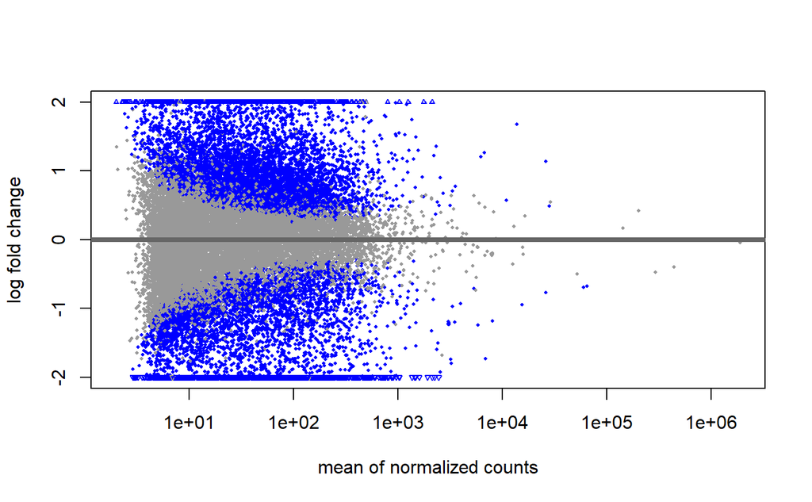

```r
plotMA(res, ylim=c(-2,2))
```

# more useful to visualize the MA-plot for the shrunken log2 fold changes

# remove the noise associated with log2 fold changes from low count genes.

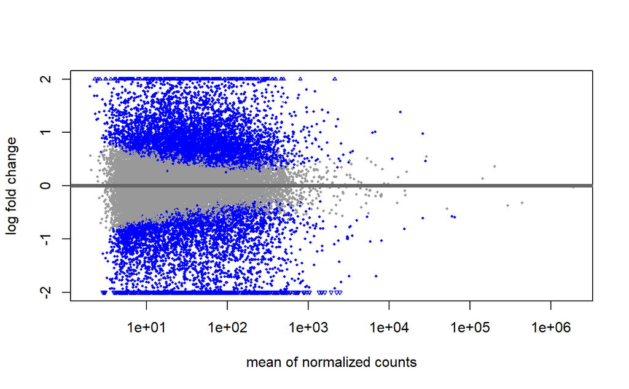

```r
plotMA(resLFC, ylim=c(-2,2))
```

# Plot counts

# Examine the counts of reads for a single gene across the groups

```r
which.min(res$padj) # index (row number) of the gene with the smallest padj
```

```
[1] 3652
```

```r
res[3652, ]
```

```
log2 fold change (MLE): tissueType Tumor vs Normal
Wald test p-value: tissueType Tumor vs Normal
DataFrame with 1 row and 6 columns
                 baseMean log2FoldChange     lfcSE      stat      pvalue        padj
                <numeric>      <numeric> <numeric> <numeric>   <numeric>   <numeric>
ENSG00000169554   735.911       -2.45901  0.145796  -16.8661 7.98605e-64 1.99316e-59
```

# ENSG00000169554 is statistically significant

# is expressed more in Normal compared to Tumor

```r
d <- plotCounts(dds, gene=which.min(res$padj), intgroup="tissueType",
                returnData=TRUE)
d
```

|  | count | tissueType |
| --- | --- | --- |
| 12S | 1483.3506 | Stroma |
| 13S | 1066.0514 | Stroma |
| 14S | 1085.6494 | Stroma |
| 15S | 831.0171 | Stroma |
| 16S | 1311.7183 | Stroma |
| 17S | 849.4137 | Stroma |
| 18S | 991.9267 | Stroma |
| 19S | 1358.0233 | Stroma |
| 20S | 1107.5387 | Stroma |
| 21S | 861.3845 | Stroma |

[output cut: 20 more lines]

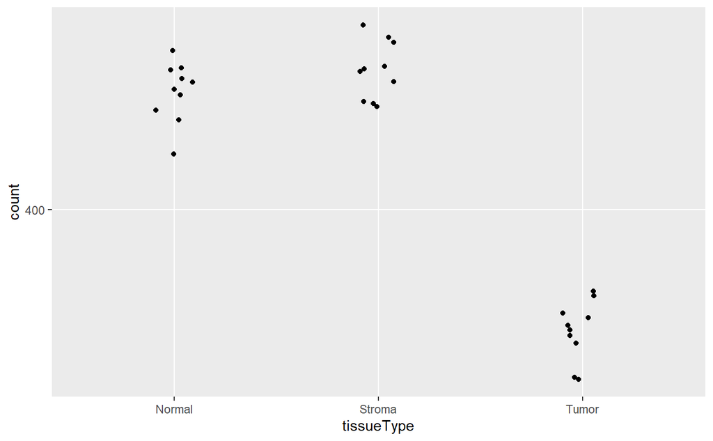

```r
ggplot(d, aes(x=tissueType, y=count)) +
  geom_point(position=position_jitter(w=0.1,h=0)) +
  scale_y_log10(breaks=c(25,100,400))
```

```r
resSig <- subset(resOrdered, padj < 0.1)
head(resSig)
```

```
log2 fold change (MLE): tissueType Tumor vs Normal
Wald test p-value: tissueType Tumor vs Normal
DataFrame with 6 rows and 6 columns
                 baseMean log2FoldChange     lfcSE      stat      pvalue        padj
                <numeric>      <numeric> <numeric> <numeric>   <numeric>   <numeric>
ENSG00000169554  735.9107       -2.45901  0.145796  -16.8661 7.98605e-64 1.99316e-59
ENSG00000179144   95.0537       -3.80644  0.242542  -15.6939 1.66430e-55 2.07687e-51
ENSG00000079819  474.5409       -2.60056  0.181933  -14.2941 2.38297e-46 1.98248e-42
ENSG00000241644  151.1108       -4.83699  0.339099  -14.2642 3.65538e-46 2.28078e-42
ENSG00000126785  110.5207       -3.49211  0.250319  -13.9506 3.11870e-44 1.55673e-40
ENSG00000125810  526.9646       -3.70978  0.275559  -13.4627 2.59177e-41 1.07809e-37
```

# Data transformations and visualization

# Use transformed versions of the count data

# Mean expression vs Variability

```r
norm_counts <- counts(dds, normalized = TRUE)

gene_means <- rowMeans(norm_counts)
gene_vars  <- apply(norm_counts, 1, var)
```

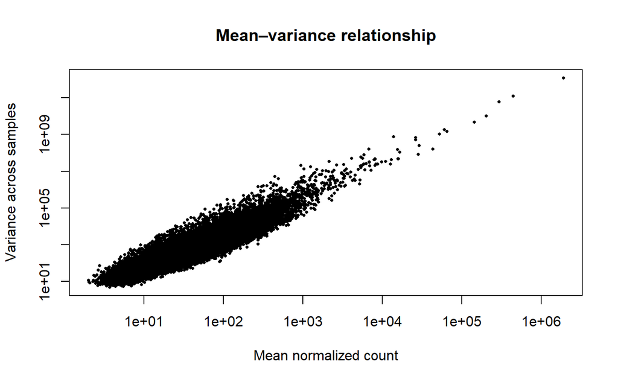

```r
plot(gene_means, gene_vars,
     log = "xy",             # log scale makes the trend visible
     pch = 16, cex = 0.5,
     xlab = "Mean normalized count",
     ylab = "Variance across samples",
     main = "Mean–variance relationship")
```

# Variability shows how much a gene’s expression changes across samples.

# Genes with higher average expression usually have higher variance.

# This means highly expressed genes can dominate clustering.

# Low- or medium-expressed genes may get ignored even if they have important patterns.

# Variance stabilization

```r
vsd <- vst(dds, blind=FALSE) # or
# rld <- rlog(dds, blind=FALSE)
```

```r
vsd_mat <- assay(vsd)
gene_means <- rowMeans(vsd_mat)
gene_vars  <- apply(vsd_mat, 1, var)
```

# Plot variance stabilized data

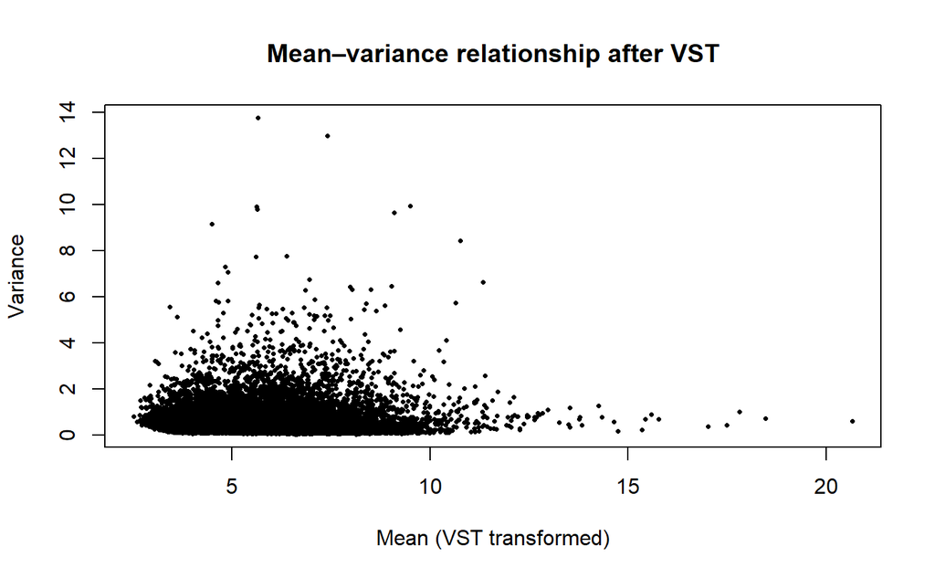

```r
plot(gene_means, gene_vars,
     pch = 16, cex = 0.5,
     xlab = "Mean (VST transformed)",
     ylab = "Variance",
     main = "Mean–variance relationship after VST")
```

# Data quality assessment by sample clustering and visualization

# Heatmaps

```r
# Compute the row means (average normalized counts) for all genes
geneMeans <- rowMeans(counts(dds, normalized = TRUE))

# Order the genes by their mean expression in decreasing order
# 'order()' returns the row indices that would sort the vector
# '[1:20]' selects the top 20 most highly expressed genes
topExpressed <- order(geneMeans, decreasing = TRUE)[1:20]

# Convert relevant sample information to a data frame for annotation
df <- as.data.frame(colData(dds))[, c("tissueType", "cancerType")]
head(df)
```

|  | tissueType | cancerType |
| --- | --- | --- |
| 12S | Stroma | squamous |
| 13S | Stroma | squamous |
| 14S | Stroma | squamous |
| 15S | Stroma | squamous |
| 16S | Stroma | adeno |
| 17S | Stroma | adeno |

```r
library(org.Hs.eg.db)
library(AnnotationDbi)
```

```r
topGenes <- rownames(counts(dds)[topExpressed, ])

geneSymbols <- mapIds(
  org.Hs.eg.db,
  keys = topGenes,
  column = "SYMBOL",
  keytype = "ENSEMBL",
  multiVals = "first"
)

# Combine into a data frame
topGenesDF <- data.frame(
  EnsemblID = topGenes,
  GeneSymbol = geneSymbols
)
topGenesDF[!is.na(topGenesDF$GeneSymbol), 2]
```

```
[1] "MALAT1"  "COX1"    "RN7SK"   "NEAT1"   "ND4"     "ND5"     "RN7SL4P" "COL1A1"
```

```r
rownames(counts(dds)[topExpressed, ])
```

```
 [1] "ENSG00000266658" "ENSG00000272060" "ENSG00000242716" "ENSG00000241335" "ENSG00000251562"
 [6] "ENSG00000210082" "ENSG00000265150" "ENSG00000265830" "ENSG00000258486" "ENSG00000211459"
[11] "ENSG00000198804" "ENSG00000202198" "ENSG00000265735" "ENSG00000245532" "ENSG00000198886"
[16] "ENSG00000266037" "ENSG00000198786" "ENSG00000263740" "ENSG00000108821" "ENSG00000259001"
```

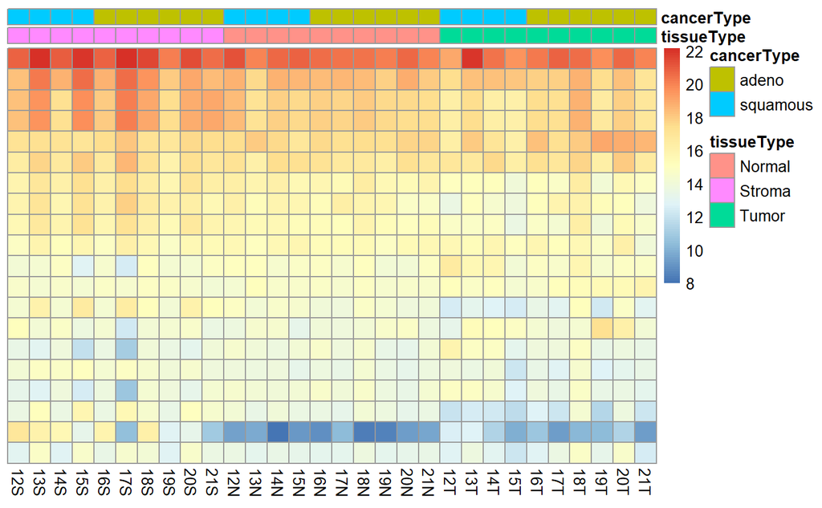

```r
library(pheatmap)

pheatmap(assay(vsd)[topExpressed,], cluster_rows=FALSE, show_rownames=FALSE,
         cluster_cols=FALSE, annotation_col=df)
```

```r
sigs <- resOrdered[!is.na(resOrdered$padj) &
                     resOrdered$padj < 0.05 &
                     abs(resOrdered$log2FoldChange) > 2, ]
dim(sigs)
```

```
[1] 1185    6
```

```r
normCounts <- counts(dds, normalized = TRUE)
sigGenes <- rownames(sigs)

# match() returns a vector of positions of genes_sig in rownames(norm_counts).
indices <- match(sigGenes, rownames(normCounts))
any(is.na(indices))
```

```
[1] FALSE
```

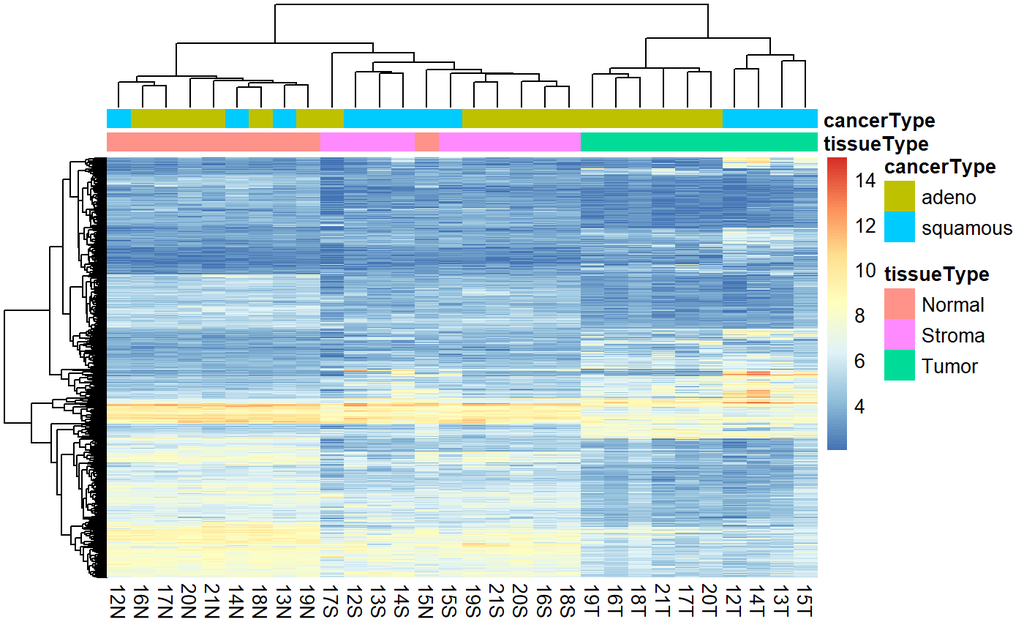

```r
pheatmap(assay(vsd)[indices,], cluster_rows=T, show_rownames=FALSE,
         cluster_cols=T, annotation_col=df)
```

# sample clustering

# Heatmap of the sample-to-sample distances

```r
sampleDists <- dist(t(assay(vsd))) # get sample-to-sample distances.
```

```r
colData(vsd)
```

```
DataFrame with 30 rows and 4 columns
     sampleName tissueType cancerType sizeFactor
    <character>   <factor>   <factor>  <numeric>
12S         12S     Stroma   squamous   1.042587
13S         13S     Stroma   squamous   0.784570
14S         14S     Stroma   squamous   1.113211
15S         15S     Stroma   squamous   0.691136
16S         16S     Stroma   adeno      0.990682
...         ...        ...        ...        ...
17T         17T      Tumor      adeno   1.102208
18T         18T      Tumor      adeno   1.202575
19T         19T      Tumor      adeno   1.251170
20T         20T      Tumor      adeno   0.987661
21T         21T      Tumor      adeno   1.488773
```

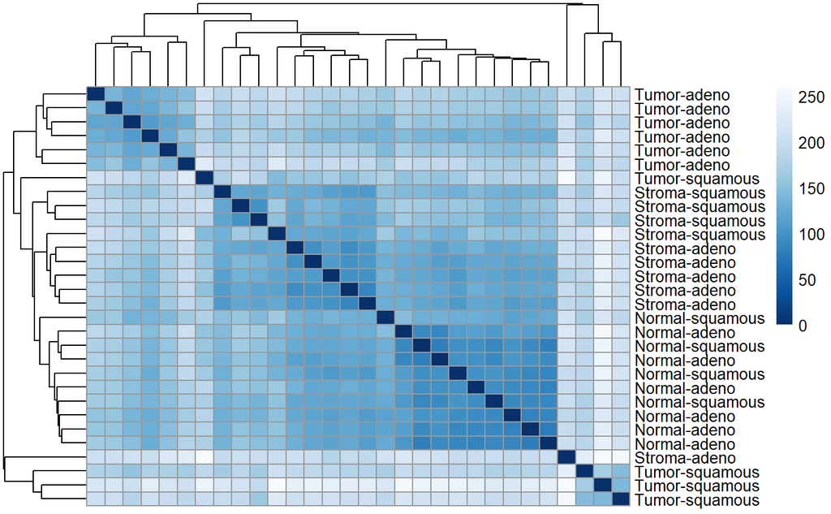

```r
library("RColorBrewer")

sampleDistMatrix <- as.matrix(sampleDists)
rownames(sampleDistMatrix) <- paste(vsd$tissueType, vsd$cancerType, sep="-")
colnames(sampleDistMatrix) <- NULL
colors <- colorRampPalette( rev(brewer.pal(9, "Blues")) )(255)

pheatmap(sampleDistMatrix,
         clustering_distance_rows=sampleDists,
         clustering_distance_cols=sampleDists,
         col=colors)
```